# Metabolomics Filtering

Sneha M. Chaturvedi

Last updated 2026-08-31

Main dataset (n = 24) filtering pipeline: - sample outlier removal (intensity and detection z-score thresholds) - retention time filtering, - missingness filtering, - annotation score filtering, - duplicate resolution,

Outputs: cleaned peak area and annotation files used by all downstream analyses.

| **Inputs** | `doc/untargeted/combined_annotations_untargeted_developing_2026.xlsx`, `doc/untargeted/24_metadata.xlsx` |
| --- | --- |
| **Outputs** | `results/untargeted/peak_area_values.csv`, `results/untargeted/metabolite_annotations.csv`, `results/untargeted/sample_metadata.csv` |
| **Upstream** | None (first script for main dataset) |
| **Downstream** | `Exogenous_Flagging.Rmd` |

# Set Up

```r
# Source Functions
source("functions.R")
source("filtering_functions.R")
```

```r
root <- find_project_root()
png_path <- file.path(root, "results/untargeted/untargeted_filtering")
csv_path <- file.path(root, "results/untargeted/untargeted_filtering/csv")
svg_path <- file.path(root, "results/untargeted/untargeted_filtering/svg")
dir.create(png_path, recursive = TRUE, showWarnings = FALSE)
dir.create(svg_path, recursive = TRUE, showWarnings = FALSE)
dir.create(csv_path, recursive = TRUE, showWarnings = FALSE)
```

## Load Dataset

```r
# Peak Area Values
full_dataset <- read_excel(file.path(root, "doc/untargeted/combined_annotations_untargeted_developing_2026.xlsx"), sheet = "Area", range = NULL)

# Metabolite Annotations
compound_annotation <- read_excel(file.path(root, "doc/untargeted/combined_annotations_untargeted_developing_2026.xlsx"), sheet = "Annotation", range = NULL)

# Sample Metadata
sample_metadata <- read_excel(file.path(root, "doc/untargeted/24_metadata.xlsx"), sheet = "metadata", range = NULL)
# Rename SampleName to Sample in metadata if needed
sample_metadata <- sample_metadata %>%
  rename(Sample = SampleName)
```

## Format Datafile

```r
#Remove pilot annotations
full_dataset <- cbind(full_dataset[1:3], full_dataset[,(12:35)])

# Clean the data
clean_metabolomics_data(full_dataset, sample_metadata, compound_annotation, dataset_name = "untargeted_raw")
```

```
##
## === Cleaning untargeted_raw ===
## Cleaning compound annotations...
## Cleaning peak intensity data...
## Renaming sample columns...
## Cleaning sample metadata...
##
## --- Cleaning Summary ---
## Dataset: untargeted_raw
## Original metabolites: 7614
## Cleaned metabolites: 6510
## Removed metabolites (all NA): 1104
## Number of samples: 24
## Samples in metadata: 24
##
## Cleaning complete!
##
## Cleaned data assigned to:
##   - untargeted_raw_peak_data
##   - untargeted_raw_sample_metadata
##   - untargeted_raw_compound_annotation
```

# Outlier Removal

## Remove Sample Outliers

Remove Samples with outlier mean metabolite intensity defined by z score threshold

```r
# Remove samples with outlier mean metabolite intensity
outlier_removal_1_results <- remove_intensity_outliers(
  data = untargeted_raw_peak_data,
  metadata = sample_metadata,
  threshold = 3,
  save_plot = TRUE,
  output_prefix = "01_intensity_outliers",
  png_path = png_path,
  csv_path = csv_path
)
```

```
##
## === Intensity Outlier Removal Summary ===
## Z-score threshold: 3
## Total samples: 24
## Outliers detected: 0
## Samples retained: 24
```

```r
# Extract filtered data
outlier_removal_1 <- outlier_removal_1_results$filtered_data

# Save filtered dataset
saveRDS(outlier_removal_1, file.path(csv_path, "outlier_removal_1.rds"))
write.csv(outlier_removal_1, file.path(csv_path, "outlier_removal_1.csv"), row.names = FALSE)
```

Remove Samples with outlier number of detected peaks

```r
# Remove samples with outlier number of detected peaks
outlier_removal_2_results <- remove_detection_outliers(
  data = outlier_removal_1, # Use output from step 1
  metadata = sample_metadata,
  threshold = 3,
  na_threshold = 0,
  save_plot = TRUE,
  output_prefix = "02_detection_outliers",
  png_path = png_path,
  csv_path = csv_path
)
```

```
##
## === Detection Outlier Removal Summary ===
## Z-score threshold: 3
## Total samples: 24
## Total peaks: 6510
## Outliers detected: 0
## Samples retained: 24
## Mean detection rate: 68.71 %
```

```r
# Extract filtered data
outlier_removal_2 <- outlier_removal_2_results$filtered_data

# Save filtered dataset
saveRDS(outlier_removal_2, file.path(csv_path, "outlier_removal_2.rds"))
write.csv(outlier_removal_2, file.path(csv_path, "outlier_removal_2.csv"), row.names = FALSE)
```

#Metabolite Filtering

## Remove Unannotated Metabolites

Create new dataframe with only annotated metabolites

```r
annotated_dataset <- outlier_removal_2[!is.na(outlier_removal_2$Name) & outlier_removal_2$Name != "", ]
unannotated_dataset <- outlier_removal_2[is.na(outlier_removal_2$Name) | outlier_removal_2$Name == "", ]
```

## Duplicate Check

```r
# Full duplicate detection with CSV output
dup_results <- detect_metabolite_duplicates(
  dataset = annotated_dataset,
  compound_annotation = untargeted_raw_compound_annotation,
  name_column = "Name",
  csv_path = csv_path,
  verbose = TRUE
)
```

```
##
##  ======================================================================
## === METABOLITE DUPLICATE DETECTION ===
## ======================================================================
##
## OVERALL STATISTICS:
##   Total metabolite identifiers: 1975
##   Unique metabolite names: 1276
##   Non-duplicate metabolites (appear once): 863
##   Duplicate metabolite names: 413
##   Total duplicate identifiers: 1112
##
## DUPLICATE SUMMARY:
## ----------------------------------------------------------------------
## # A tibble: 413 × 2
##    Name                     n_occurrences
##    <chr>                            <int>
##  1 Adenosine                           10
##  2 Inosine                             10
##  3 N-Acetyl-Neuraminic Acid             9
##  4 L-Glutathione (Reduced)              8
##  5 Adenine                              7
##  6 Creatine                             7
##  7 L-Aspartic Acid                      7
##  8 L-Glutamic Acid                      7
##  9 L-Isoleucine                         7
## 10 L-Threonine                          7
## # ℹ 403 more rows
## ----------------------------------------------------------------------
##
## Detailed duplicate information saved to: /scratch/jdlab/sneha/developing-brain-metabolomics/results/untargeted/untargeted_filtering/csv/metabolite_duplicates.csv
##
## ======================================================================
```

## Filter By Retention Time

Filter metabolites with a low retention time, found in compound annotations under RT[min]

Create visualizations to determine RT thresholds

```r
annotated_dataset_long <- prepare_long_data(annotated_dataset, untargeted_raw_sample_metadata)
```

```
## Preparing long-format data...
##   Found 24 samples
##   Dataset contains 1975 metabolites
##   Initial observations: 47400
##   Removed 11314 non-finite values
##   Log10 transformed intensity values
##   Created GW buckets: 16-18, 19-21, 22-24
##   Added metadata columns: GW, Sex, GW_bucket
##   Final observations: 36086
## Done!
```

### Display Retention Time

```r
## RETENTION TIME ANALYSIS ##

# Compute RT thresholds here so they are available for pre-filter plot below
threshold_results <- detect_rt_threshold_from_density(
  compound_annotation = untargeted_raw_compound_annotation,
  png_path = png_path,
  svg_path = svg_path,
  csv_path = csv_path
)
```

```
##
## --- Processing: Amide - Neg ---
##   Total compounds: 1326
##   RT range: 0.555 - 21.964 minutes
##
##   Bin size: 10 seconds ( 0.1666667 min)
##     First real peak at index: 4 (RT: 0.967 min, density: 26.7 )
##     Valley floor (threshold) at index: 9 (RT: 1.8 min)
##     Threshold:  1.8 min
##
## --- Processing: Amide - Pos ---
##   Total compounds: 1212
##   RT range: 0.564 - 21.994 minutes
##
##   Bin size: 10 seconds ( 0.1666667 min)
##     First real peak at index: 5 (RT: 1.143 min, density: 28.3 )
##     Valley floor (threshold) at index: 15 (RT: 2.81 min)
##     Threshold:  2.81 min
##
## --- Processing: C18 - Neg ---
##   Total compounds: 907
##   RT range: 0.522 - 21.868 minutes
##
##   Bin size: 10 seconds ( 0.1666667 min)
##     First real peak at index: 5 (RT: 1.103 min, density: 29.7 )
##     Valley floor (threshold) at index: 12 (RT: 2.27 min)
##     Threshold:  2.27 min
##
## --- Processing: C18 - Pos ---
##   Total compounds: 1661
##   RT range: 0.562 - 21.823 minutes
##
##   Bin size: 10 seconds ( 0.1666667 min)
##     First real peak at index: 7 (RT: 1.477 min, density: 20 )
##     Valley floor (threshold) at index: 9 (RT: 1.81 min)
##     Threshold:  1.81 min
##
## --- Processing: C8 - Neg ---
##   Total compounds: 750
##   RT range: 0.487 - 15.895 minutes
```

[output cut: 14 more lines]

```
##
##
## === SUMMARY OF DETECTED THRESHOLDS ===
## # A tibble: 6 × 7
##   Column Mode  BinSize_sec BinSize_min RT_threshold N_compounds RT_range
##   <chr>  <chr>       <dbl>       <dbl>        <dbl>       <int> <chr>
## 1 Amide  Neg            10       0.167         1.8         1326 0.56-21.96
## 2 Amide  Pos            10       0.167         2.81        1212 0.56-21.99
## 3 C18    Neg            10       0.167         2.27         907 0.52-21.87
## 4 C18    Pos            10       0.167         1.81        1661 0.56-21.82
## 5 C8     Neg            10       0.167         2.06         750 0.49-15.89
## 6 C8     Pos            10       0.167         1.91        1758 0.5-16
##
##
## Generating diagnostic visualizations...
```

```
##   Saved: RT_density_Amide_Neg.png
```

```
##   Saved: RT_density_Amide_Pos.png
```

```
##   Saved: RT_density_C18_Neg.png
```

```
##   Saved: RT_density_C18_Pos.png
```

```
##   Saved: RT_density_C8_Neg.png
```

```
##   Saved: RT_density_C8_Pos.png
## Diagnostic plots saved to:
##   PNG: /scratch/jdlab/sneha/developing-brain-metabolomics/results/untargeted/untargeted_filtering
##   SVG: /scratch/jdlab/sneha/developing-brain-metabolomics/results/untargeted/untargeted_filtering/svg
## Threshold summary saved to: /scratch/jdlab/sneha/developing-brain-metabolomics/results/untargeted/untargeted_filtering/csv/RT_threshold_summary.csv
```

```r
# Calculate metabolite abundance
metabolite_abundance <- calculate_metabolite_abundance(
  dataset = annotated_dataset,
  sample_cols = 4:27,
  compound_annotation = untargeted_raw_compound_annotation
)
```

```
## Calculating metabolite abundance...
##   Samples: 24
##   Metabolites: 1975
##   Added compound annotations
## Done!
```

```r
metabolite_abundance_by_sex <- calculate_metabolite_abundance_by_group(
  data_long = annotated_dataset_long,
  group_by = "Sex",
  dataset = annotated_dataset,
  compound_annotation = untargeted_raw_compound_annotation
)
```

```
## Calculating metabolite abundance by Sex ...
## Done!
```

```r
metabolite_abundance_by_gw <- calculate_metabolite_abundance_by_group(
  data_long = annotated_dataset_long,
  group_by = "GW_bucket",
  dataset = annotated_dataset,
  compound_annotation = untargeted_raw_compound_annotation
)
```

```
## Calculating metabolite abundance by GW_bucket ...
## Done!
```

```r
# Add retention time to metabolite abundance data
metabolite_abundance_with_RT <- metabolite_abundance %>%
  left_join(compound_annotation %>% dplyr::select(Compound.ID, `RT[min]`), by = "Compound.ID") %>%
  rename(RT = `RT[min]`)

# Distribution of retention time across samples - Histogram
RT_distribution_histogram <- ggplot(metabolite_abundance_with_RT, aes(x = RT)) +
  geom_histogram(binwidth = 0.5, fill = "steelblue", color = "black") +
  theme_minimal() +
  labs(
    title = "Distribution of Retention Time Across Metabolites",
    x = "Retention Time (min)",
    y = "Metabolite Count"
  ) +
  theme(plot.margin = margin(10, 10, 10, 10))

save_dual_format(RT_distribution_histogram, "RT_distribution_histogram", png_path = png_path, svg_path = svg_path)

# By Sex
metabolite_abundance_by_sex_with_RT <- metabolite_abundance_by_sex %>%
  left_join(compound_annotation %>% dplyr::select(Compound.ID, `RT[min]`), by = "Compound.ID") %>%
  rename(RT = `RT[min]`)

RT_distribution_by_sex <- ggplot(metabolite_abundance_by_sex_with_RT, aes(x = RT, fill = Sex)) +
  geom_histogram(binwidth = 0.5, color = "black", position = "identity", alpha = 0.6) +
  theme_minimal() +
  labs(
    title = "Distribution of Retention Time by Sex",
    x = "Retention Time (min)",
    y = "Metabolite Count"
  ) +
  facet_wrap(~Sex, ncol = 1)

save_dual_format(RT_distribution_by_sex, "RT_distribution_by_sex", png_path = png_path, svg_path = svg_path)

# By Gestational Week Bucket
metabolite_abundance_by_GW_with_RT <- metabolite_abundance_by_gw %>%
  left_join(compound_annotation %>% dplyr::select(Compound.ID, `RT[min]`), by = "Compound.ID") %>%
  rename(RT = `RT[min]`)

RT_distribution_by_GW <- ggplot(metabolite_abundance_by_GW_with_RT, aes(x = RT, fill = GW_bucket)) +
  geom_histogram(binwidth = 0.5, color = "black", position = "identity", alpha = 0.6) +
  theme_minimal() +
  labs(
    title = "Distribution of Retention Time by GW Bucket",
    x = "Retention Time (min)",
    y = "Metabolite Count"
  ) +
  facet_wrap(~GW_bucket, ncol = 1)

save_dual_format(RT_distribution_by_GW, "RT_distribution_by_GW", png_path = png_path, svg_path = svg_path)

# Time x Intensity Scatter plot per column for Super.Class
# Create dataset with metabolite with known Super.Class and extract column from Compound.ID
metabolite_RT_intensity_superclass <- metabolite_abundance_with_RT %>%
  filter(!is.na(Super.Class) & Super.Class != "" & !is.na(RT)) %>%
  mutate(log10 = log10(mean_intensity)) %>%
  mutate(Column = sub("-[^-]+-[0-9]+$", "", Compound.ID)) %>% # Extract column from Compound.ID
  mutate(Mode = sub(".*-(.*?)-.*", "\\1", Compound.ID))



RT_intensity_column_superclass <- ggplot(metabolite_RT_intensity_superclass, aes(x = RT, y = log10, color = Super.Class)) +
  geom_point(alpha = 0.6, size = 2) +
  facet_wrap(~Column, scales = "free") +
  theme_minimal() +
  labs(
    title = "Retention Time vs Intensity by Column",
    x = "Retention Time (min)",
    y = "Log10 Mean Peak Intensity"
  ) +
  theme(legend.position = "right", axis.text.x = element_text(angle = 45, hjust = 1))

save_dual_format(RT_intensity_column_superclass, "RT_intensity_column_superclass", png_path = png_path, svg_path = svg_path)

# Build per-facet threshold lines from density-detected thresholds
rt_thresholds_for_plot <- threshold_results$recommended_thresholds

RT_intensity_column_mode_superclass <- ggplot(metabolite_RT_intensity_superclass, aes(x = RT, y = log10, color = Super.Class)) +
  geom_point(alpha = 0.6, size = 2) +
  geom_vline(
    data = rt_thresholds_for_plot,
    aes(xintercept = RT_cutoff),
    color = "red", linetype = "dashed", linewidth = 0.8,
    inherit.aes = FALSE
  ) +
  facet_wrap(~ Column + Mode, scales = "free") +
  theme_minimal() +
  labs(
    title = "Retention Time vs Intensity by Column and Mode",
    subtitle = "Red dashed line = RT threshold",
    x = "Retention Time (min)",
    y = "Log10 Mean Peak Intensity"
  ) +
  theme(legend.position = "right", axis.text.x = element_text(angle = 45, hjust = 1))
save_dual_format(RT_intensity_column_mode_superclass, "RT_intensity_column_mode_superclass", png_path = png_path, svg_path = svg_path)

# Zoomed version: 0-5 minutes with 30-second intervals
RT_intensity_column_mode_superclass_zoomed <- ggplot(metabolite_RT_intensity_superclass, aes(x = RT, y = log10, color = Super.Class)) +
  geom_point(alpha = 0.6, size = 2) +
  facet_wrap(~ Column + Mode, scales = "free_y") + # Changed to free_y only, so x-axis is consistent
  scale_x_continuous(breaks = seq(0, 5, by = 0.5), limits = c(0, 5)) + # Add this line for zoom and tick marks
  theme_minimal() +
  labs(
    title = "Retention Time vs Intensity by Column and Mode (0-5 min)",
    x = "Retention Time (min)",
    y = "Log10 Mean Peak Intensity"
  ) +
  theme(legend.position = "right", axis.text.x = element_text(angle = 45, hjust = 1))

save_dual_format(RT_intensity_column_mode_superclass_zoomed, "RT_intensity_column_mode_superclass_zoomed_0-5min", png_path = png_path, svg_path = svg_path)
```

### Display Column Composition

```r
## BAR GRAPHS: METABOLITE COUNTS BY CLASSIFICATION AND COLUMN-MODE ##

# 1. Super.Class counts by Column-Mode
superclass_counts <- metabolite_RT_intensity_superclass %>%
  group_by(Column, Mode, Super.Class) %>%
  summarise(n_metabolites = n(), .groups = "drop") %>%
  mutate(Column_Mode = paste(Column, Mode, sep = "_"))

superclass_barplot <- ggplot(superclass_counts, aes(x = Super.Class, y = n_metabolites, fill = Mode)) +
  geom_bar(stat = "identity", position = "dodge", color = "black") +
  facet_wrap(~Column, scales = "free_y") +
  theme_minimal() +
  labs(
    title = "Metabolite Count by Super.Class and Column-Mode",
    x = "Super.Class",
    y = "Number of Metabolites"
  ) +
  theme(
    axis.text.x = element_text(angle = 45, hjust = 1, size = 8),
    legend.position = "bottom"
  )

save_dual_format(superclass_barplot, "metabolite_counts_by_superclass_column_mode", png_path = png_path, svg_path = svg_path)

# 2. Class counts by Column-Mode
# Need to use metabolite_abundance_with_RT since Class isn't in the superclass-filtered dataset
class_counts <- metabolite_abundance_with_RT %>%
  filter(!is.na(Class) & Class != "") %>%
  mutate(
    Column = sub("-[^-]+-[0-9]+$", "", Compound.ID),
    Mode = sub(".*-(.*?)-.*", "\\1", Compound.ID)
  ) %>%
  filter(!is.na(Column) & !is.na(Mode)) %>%
  group_by(Column, Mode, Class) %>%
  summarise(n_metabolites = n(), .groups = "drop") %>%
  mutate(Column_Mode = paste(Column, Mode, sep = "_"))

# show top 20 per column-mode
top_classes <- class_counts %>%
  group_by(Column, Mode) %>%
  slice_max(order_by = n_metabolites, n = 20) %>%
  ungroup()


class_barplot <- ggplot(top_classes, aes(x = reorder(Class, n_metabolites), y = n_metabolites, fill = Mode)) +
  geom_bar(stat = "identity", color = "black") +
  facet_wrap(~Column, scales = "free") +
  coord_flip() + # Flip for readability
  theme_minimal() +
  labs(
    title = "Top 20 Classes by Metabolite Count (by Column-Mode)",
    x = "Class",
    y = "Number of Metabolites"
  ) +
  theme(
    axis.text.y = element_text(size = 7),
    legend.position = "bottom"
  )

save_dual_format(class_barplot, "metabolite_counts_by_class_column_mode_top20", png_path = png_path, svg_path = svg_path)

# 3. Sub.Class counts by Column-Mode
subclass_counts <- metabolite_abundance_with_RT %>%
  filter(!is.na(Sub.Class) & Sub.Class != "") %>%
  mutate(
    Column = sub("-[^-]+-[0-9]+$", "", Compound.ID),
    Mode = sub(".*-(.*?)-.*", "\\1", Compound.ID)
  ) %>%
  filter(!is.na(Column) & !is.na(Mode)) %>%
  group_by(Column, Mode, Sub.Class) %>%
  summarise(n_metabolites = n(), .groups = "drop") %>%
  mutate(Column_Mode = paste(Column, Mode, sep = "_"))

# show top 20 sub.class per column-mode
top_subclasses <- subclass_counts %>%
  group_by(Column, Mode) %>%
  slice_max(order_by = n_metabolites, n = 20) %>%
  ungroup()

subclass_barplot <- ggplot(top_subclasses, aes(x = reorder(Sub.Class, n_metabolites), y = n_metabolites, fill = Mode)) +
  geom_bar(stat = "identity", color = "black") +
  facet_wrap(~Column, scales = "free") +
  coord_flip() + # Flip for readability
  theme_minimal() +
  labs(
    title = "Top 20 Sub.Classes by Metabolite Count (by Column-Mode)",
    x = "Sub.Class",
    y = "Number of Metabolites"
  ) +
  theme(
    axis.text.y = element_text(size = 7),
    legend.position = "bottom"
  )

save_dual_format(subclass_barplot, "metabolite_counts_by_subclass_column_mode_top20", png_path = png_path, svg_path = svg_path)

# 4. Summary table by Column-Mode
summary_by_column_mode <- metabolite_abundance_with_RT %>%
  mutate(
    Column = sub("-[^-]+-[0-9]+$", "", Compound.ID),
    Mode = sub(".*-(.*?)-.*", "\\1", Compound.ID)
  ) %>%
  filter(!is.na(Column) & !is.na(Mode)) %>%
  group_by(Column, Mode) %>%
  summarise(
    total_metabolites = n(),
    n_superclasses = n_distinct(Super.Class[!is.na(Super.Class) & Super.Class != ""]),
    n_classes = n_distinct(Class[!is.na(Class) & Class != ""]),
    n_subclasses = n_distinct(Sub.Class[!is.na(Sub.Class) & Sub.Class != ""]),
    .groups = "drop"
  )

print("Summary of metabolite diversity by Column-Mode:")
```

```
## [1] "Summary of metabolite diversity by Column-Mode:"
```

```r
print(summary_by_column_mode)
```

```
## # A tibble: 6 × 6
##   Column Mode  total_metabolites n_superclasses n_classes n_subclasses
##   <chr>  <chr>             <int>          <int>     <int>        <int>
## 1 Amide  Neg                 325              8        38           64
## 2 Amide  Pos                 392              9        45           75
## 3 C18    Neg                 140              7        21           29
## 4 C18    Pos                 311              9        47           62
## 5 C8     Neg                 171              6        15           27
## 6 C8     Pos                 636             10        57          100
```

```r
# 5. Alternative: Stacked bar showing all column-modes side by side for each Super.Class
superclass_stacked <- ggplot(superclass_counts, aes(x = Column_Mode, y = n_metabolites, fill = Super.Class)) +
  geom_bar(stat = "identity", color = "black") +
  theme_minimal() +
  labs(
    title = "Metabolite Distribution by Super.Class across Column-Mode Combinations",
    x = "Column-Mode Combination",
    y = "Number of Metabolites"
  ) +
  theme(
    axis.text.x = element_text(angle = 45, hjust = 1),
    legend.position = "right"
  )

save_dual_format(superclass_stacked, "metabolite_counts_superclass_stacked_by_column_mode", png_path = png_path, svg_path = svg_path)
```

### Determine RT Threshold + Filter

```r
# View recommended thresholds
threshold_results$recommended_thresholds
```

```
## # A tibble: 6 × 3
##   Column Mode  RT_cutoff
##   <chr>  <chr>     <dbl>
## 1 Amide  Neg        1.8
## 2 Amide  Pos        2.81
## 3 C18    Neg        2.27
## 4 C18    Pos        1.81
## 5 C8     Neg        2.06
## 6 C8     Pos        1.91
```

```r
# Apply to dataset
filtering_results <- apply_density_detected_thresholds(
  dataset = annotated_dataset,
  compound_annotation = untargeted_raw_compound_annotation,
  threshold_results = threshold_results
)
```

```
##
## === APPLYING DENSITY-DETECTED THRESHOLDS ===
## Using 6 column-mode combinations
##
## # A tibble: 6 × 3
##   Column Mode  RT_cutoff
##   <chr>  <chr>     <dbl>
## 1 Amide  Neg        1.8
## 2 Amide  Pos        2.81
## 3 C18    Neg        2.27
## 4 C18    Pos        1.81
## 5 C8     Neg        2.06
## 6 C8     Pos        1.91
##
##  ============================================================
## === RT THRESHOLD FILTERING SUMMARY ===
## ============================================================
##
## DETECTION METHOD: Density-based (first significant drop)
## BIN SIZE: 10 seconds
##
## OVERALL STATISTICS:
##   Total compounds before filtering: 1975
##   Total compounds after filtering: 1727
##   Compounds removed: 248
##   Percent retained: 87.4 %
##
## THRESHOLDS APPLIED BY COLUMN-MODE:
## ------------------------------------------------------------
## # A tibble: 6 × 7
##   Column Mode  RT_cutoff total below_cutoff above_cutoff percent_retained
##   <chr>  <chr>     <dbl> <int>        <int>        <int>            <dbl>
## 1 Amide  Neg        1.8   1326          128         1198             90.3
## 2 Amide  Pos        2.81  1212          153         1059             87.4
## 3 C18    Neg        2.27   907          221          686             75.6
## 4 C18    Pos        1.81  1661          100         1561             94
## 5 C8     Neg        2.06   750          127          623             83.1
## 6 C8     Pos        1.91  1758           98         1660             94.4
## ------------------------------------------------------------
##
## DETECTION STATISTICS (filtered dataset):
##   Total compounds: 1727
##   Total samples: 24
##   Total peak measurements: 41448
##   Mean detection rate: 75.61 %
##
## ============================================================
```

```r
# Use filtered dataset
annotated_dataset_RT_filtered <- filtering_results$filtered_dataset

# create long version
prepare_long_data(annotated_dataset_RT_filtered, untargeted_raw_sample_metadata, data_name = "annotated_dataset_long_RT_filtered")
```

```
## Preparing long-format data...
##   Found 24 samples
##   Dataset contains 1727 metabolites
##   Initial observations: 41448
##   Removed 10110 non-finite values
##   Log10 transformed intensity values
##   Created GW buckets: 16-18, 19-21, 22-24
##   Added metadata columns: GW, Sex, GW_bucket
##   Final observations: 31338
## Done!
```

```
## # A tibble: 31,338 × 10
##    Compound.ID      Name    Formula Sample Intensity log10    GW Sex   GW_bucket
##    <chr>            <chr>   <chr>   <chr>      <dbl> <dbl> <dbl> <chr> <chr>
##  1 Amide-Neg-000001 Acryli… C3 H4 … Sampl… 20592498.  7.31    21 F     19-21
##  2 Amide-Neg-000001 Acryli… C3 H4 … Sampl… 26047860.  7.42    22 F     22-24
##  3 Amide-Neg-000001 Acryli… C3 H4 … Sampl… 24991982.  7.40    22 M     22-24
##  4 Amide-Neg-000001 Acryli… C3 H4 … Sampl… 17783941.  7.25    21 F     19-21
##  5 Amide-Neg-000001 Acryli… C3 H4 … Sampl… 28185664.  7.45    22 M     22-24
##  6 Amide-Neg-000001 Acryli… C3 H4 … Sampl… 31707640.  7.50    22 F     22-24
##  7 Amide-Neg-000001 Acryli… C3 H4 … Sampl… 46578786.  7.67    21 M     19-21
##  8 Amide-Neg-000001 Acryli… C3 H4 … Sampl… 33613511.  7.53    18 M     16-18
##  9 Amide-Neg-000001 Acryli… C3 H4 … Sampl… 34928621.  7.54    23 F     22-24
## 10 Amide-Neg-000001 Acryli… C3 H4 … Sampl… 12422579.  7.09    18 M     16-18
## # ℹ 31,328 more rows
## # ℹ 1 more variable: SampleLabel <chr>
```

### Post RT Filter Duplicate Check

```r
check_duplicates(annotated_dataset_RT_filtered)
```

```
##
## === OVERALL STATISTICS ===
##   Total metabolite identifiers: 1727
##   Unique metabolite names: 1183
##   Non-duplicate metabolites (appear once): 821
##   Duplicate metabolite names: 362
##   Total duplicate identifiers: 906
```

### Check RT Post Filtering

Re-check column composition after filtering:

```r
# Calculate metabolite abundance
metabolite_abundance <- calculate_metabolite_abundance(
  dataset = annotated_dataset_RT_filtered,
  sample_cols = 4:27,
  compound_annotation = untargeted_raw_compound_annotation
)
```

```
## Calculating metabolite abundance...
##   Samples: 24
##   Metabolites: 1727
##   Added compound annotations
## Done!
```

```r
metabolite_abundance_by_sex <- calculate_metabolite_abundance_by_group(
  data_long = annotated_dataset_long_RT_filtered,
  group_by = "Sex",
  dataset = annotated_dataset_RT_filtered,
  compound_annotation = untargeted_raw_compound_annotation
)
```

```
## Calculating metabolite abundance by Sex ...
## Done!
```

```r
metabolite_abundance_by_gw <- calculate_metabolite_abundance_by_group(
  data_long = annotated_dataset_long_RT_filtered,
  group_by = "GW_bucket",
  dataset = annotated_dataset_RT_filtered,
  compound_annotation = untargeted_raw_compound_annotation
)
```

```
## Calculating metabolite abundance by GW_bucket ...
## Done!
```

```r
# Add retention time to metabolite abundance data
metabolite_abundance_with_RT <- metabolite_abundance %>%
  left_join(compound_annotation %>% dplyr::select(Compound.ID, `RT[min]`), by = "Compound.ID") %>%
  rename(RT = `RT[min]`)

# Distribution of retention time across samples - Histogram
RT_distribution_histogram <- ggplot(metabolite_abundance_with_RT, aes(x = RT)) +
  geom_histogram(binwidth = 0.5, fill = "steelblue", color = "black") +
  theme_minimal() +
  labs(
    title = "Distribution of Retention Time Across Metabolites",
    x = "Retention Time (min)",
    y = "Metabolite Count"
  ) +
  theme(plot.margin = margin(10, 10, 10, 10))

save_dual_format(RT_distribution_histogram, "Filtered_RT_distribution_histogram", png_path = png_path, svg_path = svg_path)

# By Sex
metabolite_abundance_by_sex_with_RT <- metabolite_abundance_by_sex %>%
  left_join(compound_annotation %>% dplyr::select(Compound.ID, `RT[min]`), by = "Compound.ID") %>%
  rename(RT = `RT[min]`)

RT_distribution_by_sex <- ggplot(metabolite_abundance_by_sex_with_RT, aes(x = RT, fill = Sex)) +
  geom_histogram(binwidth = 0.5, color = "black", position = "identity", alpha = 0.6) +
  theme_minimal() +
  labs(
    title = "Distribution of Retention Time by Sex",
    x = "Retention Time (min)",
    y = "Metabolite Count"
  ) +
  facet_wrap(~Sex, ncol = 1)

save_dual_format(RT_distribution_by_sex, "Filtered_RT_distribution_by_sex", png_path = png_path, svg_path = svg_path)

# By Gestational Week Bucket
metabolite_abundance_by_GW_with_RT <- metabolite_abundance_by_gw %>%
  left_join(compound_annotation %>% dplyr::select(Compound.ID, `RT[min]`), by = "Compound.ID") %>%
  rename(RT = `RT[min]`)

RT_distribution_by_GW <- ggplot(metabolite_abundance_by_GW_with_RT, aes(x = RT, fill = GW_bucket)) +
  geom_histogram(binwidth = 0.5, color = "black", position = "identity", alpha = 0.6) +
  theme_minimal() +
  labs(
    title = "Distribution of Retention Time by GW Bucket",
    x = "Retention Time (min)",
    y = "Metabolite Count"
  ) +
  facet_wrap(~GW_bucket, ncol = 1)

save_dual_format(RT_distribution_by_GW, "Filtered_RT_distribution_by_GW", png_path = png_path, svg_path = svg_path)

# Time x Intensity Scatter plot per column for Super.Class
# Create dataset with metabolite with known Super.Class and extract column from Compound.ID
metabolite_RT_intensity_superclass <- metabolite_abundance_with_RT %>%
  filter(!is.na(Super.Class) & Super.Class != "" & !is.na(RT)) %>%
  mutate(log10 = log10(mean_intensity)) %>%
  mutate(Column = sub("-[^-]+-[0-9]+$", "", Compound.ID)) %>% # Extract column from Compound.ID
  mutate(Mode = sub(".*-(.*?)-.*", "\\1", Compound.ID))



RT_intensity_column_superclass <- ggplot(metabolite_RT_intensity_superclass, aes(x = RT, y = log10, color = Super.Class)) +
  geom_point(alpha = 0.6, size = 2) +
  facet_wrap(~Column, scales = "free") +
  theme_minimal() +
  labs(
    title = "Retention Time vs Intensity by Column",
    x = "Retention Time (min)",
    y = "Log10 Mean Peak Intensity"
  ) +
  theme(legend.position = "right", axis.text.x = element_text(angle = 45, hjust = 1))

save_dual_format(RT_intensity_column_superclass, "Filtered_RT_intensity_column_superclass", png_path = png_path, svg_path = svg_path)

RT_intensity_column_mode_superclass <- ggplot(metabolite_RT_intensity_superclass, aes(x = RT, y = log10, color = Super.Class)) +
  geom_point(alpha = 0.6, size = 2) +
  facet_wrap(~ Column + Mode, scales = "free") +
  theme_minimal() +
  labs(
    title = "Retention Time vs Intensity by Column and Mode",
    x = "Retention Time (min)",
    y = "Log10 Mean Peak Intensity"
  ) +
  theme(legend.position = "right", axis.text.x = element_text(angle = 45, hjust = 1))

save_dual_format(RT_intensity_column_mode_superclass, "Filtered_RT_intensity_column_mode_superclass", png_path = png_path, svg_path = svg_path)
```

### Check Column Composition Post Filtering

```r
## BAR GRAPHS: METABOLITE COUNTS BY CLASSIFICATION AND COLUMN-MODE ##

# 1. Super.Class counts by Column-Mode
superclass_counts <- metabolite_RT_intensity_superclass %>%
  group_by(Column, Mode, Super.Class) %>%
  summarise(n_metabolites = n(), .groups = "drop") %>%
  mutate(Column_Mode = paste(Column, Mode, sep = "_"))

superclass_barplot <- ggplot(superclass_counts, aes(x = Super.Class, y = n_metabolites, fill = Mode)) +
  geom_bar(stat = "identity", position = "dodge", color = "black") +
  facet_wrap(~Column, scales = "free_y") +
  theme_minimal() +
  labs(
    title = "Metabolite Count by Super.Class and Column-Mode",
    x = "Super.Class",
    y = "Number of Metabolites"
  ) +
  theme(
    axis.text.x = element_text(angle = 45, hjust = 1, size = 8),
    legend.position = "bottom"
  )

save_dual_format(superclass_barplot, "Filtered_metabolite_counts_by_superclass_column_mode", png_path = png_path, svg_path = svg_path)

# 2. Class counts by Column-Mode
# Need to use metabolite_abundance_with_RT since Class isn't in the superclass-filtered dataset
class_counts <- metabolite_abundance_with_RT %>%
  filter(!is.na(Class) & Class != "") %>%
  mutate(
    Column = sub("-[^-]+-[0-9]+$", "", Compound.ID),
    Mode = sub(".*-(.*?)-.*", "\\1", Compound.ID)
  ) %>%
  filter(!is.na(Column) & !is.na(Mode)) %>%
  group_by(Column, Mode, Class) %>%
  summarise(n_metabolites = n(), .groups = "drop") %>%
  mutate(Column_Mode = paste(Column, Mode, sep = "_"))

# show top 20 per column-mode
top_classes <- class_counts %>%
  group_by(Column, Mode) %>%
  slice_max(order_by = n_metabolites, n = 20) %>%
  ungroup()


class_barplot <- ggplot(top_classes, aes(x = reorder(Class, n_metabolites), y = n_metabolites, fill = Mode)) +
  geom_bar(stat = "identity", color = "black") +
  facet_wrap(~Column, scales = "free") +
  coord_flip() + # Flip for readability
  theme_minimal() +
  labs(
    title = "Top 20 Classes by Metabolite Count (by Column-Mode)",
    x = "Class",
    y = "Number of Metabolites"
  ) +
  theme(
    axis.text.y = element_text(size = 7),
    legend.position = "bottom"
  )

save_dual_format(class_barplot, "Filtered_metabolite_counts_by_class_column_mode_top20", png_path = png_path, svg_path = svg_path)

# 3. Sub.Class counts by Column-Mode
subclass_counts <- metabolite_abundance_with_RT %>%
  filter(!is.na(Sub.Class) & Sub.Class != "") %>%
  mutate(
    Column = sub("-[^-]+-[0-9]+$", "", Compound.ID),
    Mode = sub(".*-(.*?)-.*", "\\1", Compound.ID)
  ) %>%
  filter(!is.na(Column) & !is.na(Mode)) %>%
  group_by(Column, Mode, Sub.Class) %>%
  summarise(n_metabolites = n(), .groups = "drop") %>%
  mutate(Column_Mode = paste(Column, Mode, sep = "_"))

# Sub.Class might have many categories, so let's show top 20 per column-mode
top_subclasses <- subclass_counts %>%
  group_by(Column, Mode) %>%
  slice_max(order_by = n_metabolites, n = 20) %>%
  ungroup()

subclass_barplot <- ggplot(top_subclasses, aes(x = reorder(Sub.Class, n_metabolites), y = n_metabolites, fill = Mode)) +
  geom_bar(stat = "identity", color = "black") +
  facet_wrap(~Column, scales = "free") +
  coord_flip() + # Flip for readability
  theme_minimal() +
  labs(
    title = "Top 20 Sub.Classes by Metabolite Count (by Column-Mode)",
    x = "Sub.Class",
    y = "Number of Metabolites"
  ) +
  theme(
    axis.text.y = element_text(size = 7),
    legend.position = "bottom"
  )

save_dual_format(subclass_barplot, "Filtered_metabolite_counts_by_subclass_column_mode_top20", png_path = png_path, svg_path = svg_path)

# 4. Summary table by Column-Mode
summary_by_column_mode <- metabolite_abundance_with_RT %>%
  mutate(
    Column = sub("-[^-]+-[0-9]+$", "", Compound.ID),
    Mode = sub(".*-(.*?)-.*", "\\1", Compound.ID)
  ) %>%
  filter(!is.na(Column) & !is.na(Mode)) %>%
  group_by(Column, Mode) %>%
  summarise(
    total_metabolites = n(),
    n_superclasses = n_distinct(Super.Class[!is.na(Super.Class) & Super.Class != ""]),
    n_classes = n_distinct(Class[!is.na(Class) & Class != ""]),
    n_subclasses = n_distinct(Sub.Class[!is.na(Sub.Class) & Sub.Class != ""]),
    .groups = "drop"
  )

print("Summary of metabolite diversity by Column-Mode:")
```

```
## [1] "Summary of metabolite diversity by Column-Mode:"
```

```r
print(summary_by_column_mode)
```

```
## # A tibble: 6 × 6
##   Column Mode  total_metabolites n_superclasses n_classes n_subclasses
##   <chr>  <chr>             <int>          <int>     <int>        <int>
## 1 Amide  Neg                 279              8        34           51
## 2 Amide  Pos                 335              8        34           56
## 3 C18    Neg                  85              7        18           20
## 4 C18    Pos                 264              9        45           59
## 5 C8     Neg                 159              5        11           21
## 6 C8     Pos                 605             10        53           96
```

```r
# 5. Alternative: Stacked bar showing all column-modes side by side for each Super.Class
superclass_stacked <- ggplot(superclass_counts, aes(x = Column_Mode, y = n_metabolites, fill = Super.Class)) +
  geom_bar(stat = "identity", color = "black") +
  theme_minimal() +
  labs(
    title = "Metabolite Distribution by Super.Class across Column-Mode Combinations",
    x = "Column-Mode Combination",
    y = "Number of Metabolites"
  ) +
  theme(
    axis.text.x = element_text(angle = 45, hjust = 1),
    legend.position = "right"
  )

save_dual_format(superclass_stacked, "Filtered_metabolite_counts_superclass_stacked_by_column_mode", png_path = png_path, svg_path = svg_path)
```

## Filter by Metabolite Missingness

Filter out metabolites present in fewer than 50% of samples (threshold lowered to retain metabolites that may only be detected in one sex).

```r
# Filter metabolites
missingness_results <- filter_metabolites_by_missingness(
  dataset = annotated_dataset_RT_filtered,
  compound_annotation = untargeted_raw_compound_annotation,
  detection_threshold = 0.50,
  verbose = TRUE
)
```

```
##
## Determining sample columns...
##   Sample columns identified: 24
##
##  ======================================================================
## === MISSINGNESS-BASED FILTERING SUMMARY ===
## ======================================================================
##
## FILTERING CRITERIA:
##   Detection threshold: ≥ 50 % of samples
##   Minimum detected samples per metabolite: 12
##   Total samples analyzed: 24
##
## OVERALL STATISTICS:
##   Total metabolites before filtering: 1727
##   Total metabolites after filtering: 1333
##   Metabolites removed: 394
##   Percent retained: 77.19 %
##
## DETECTION RATE STATISTICS (before filtering):
##   Mean detection rate: 75.61 %
##   Median detection rate: 95.83 %
##   Min detection rate: 4.17 %
##   Max detection rate: 100 %
##
## DETECTION RATE STATISTICS (after filtering):
##   Mean detection rate: 91.39 %
##   Median detection rate: 100 %
##   Min detection rate: 50 %
##   Max detection rate: 100 %
##
## METABOLITES REMOVED BY DETECTION RATE:
##     0.0 - 25.0 % detected:  217
##    25.0 - 50.0 % detected:  177
##    50.0 - 75.0 % detected:  0
##
## SAMPLE-WISE DETECTION RATE (filtered dataset):
##   Mean across samples: 91.39 %
##   Range: 87.85 - 93.32 %
##
## ======================================================================
```

```r
# Assign the filtered dataset
annotated_dataset_missingness_filtered <- missingness_results$filtered_dataset

# Plot with separate paths
p_missingness <- plot_missingness_distribution(
  missingness_stats = missingness_results$missingness_stats,
  detection_threshold = 0.50,
  png_path = png_path,
  svg_path = svg_path
)
```

```
## PNG plot saved to: /scratch/jdlab/sneha/developing-brain-metabolomics/results/untargeted/untargeted_filtering/missingness_distribution.png
```

```
## SVG plot saved to: /scratch/jdlab/sneha/developing-brain-metabolomics/results/untargeted/untargeted_filtering/svg/missingness_distribution.svg
```

### Post Missingness Filter Duplicate Check

```r
check_duplicates(annotated_dataset_missingness_filtered)
```

```
##
## === OVERALL STATISTICS ===
##   Total metabolite identifiers: 1333
##   Unique metabolite names: 989
##   Non-duplicate metabolites (appear once): 732
##   Duplicate metabolite names: 257
##   Total duplicate identifiers: 601
```

## Filter by Annotation Score

Inspect the distribution of annotation scores to determine a quality threshold. Metabolites below the chosen threshold will be removed before de-duplication.

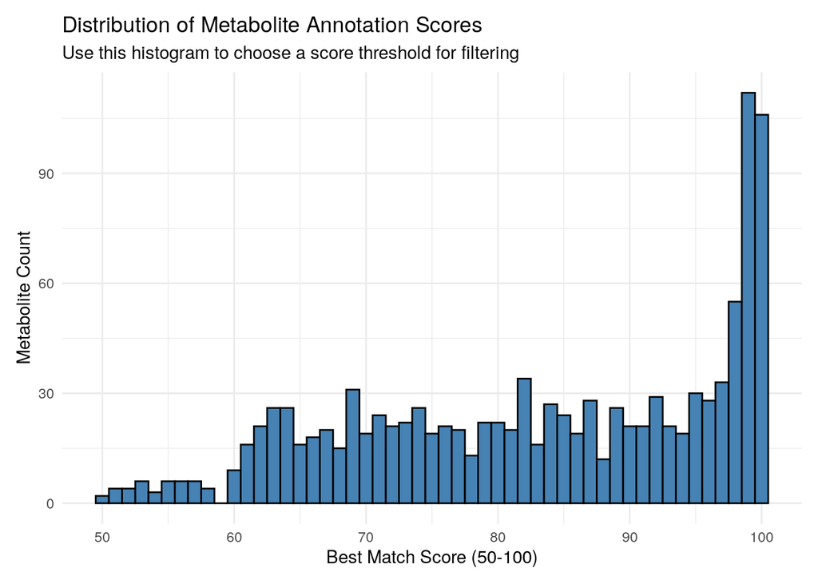

```r
# Join annotation scores to the missingness-filtered dataset
annotation_scores <- untargeted_raw_compound_annotation %>%
  dplyr::select(Compound.ID, Best.Match, Library.Name) %>%
  distinct()

score_data <- annotated_dataset_missingness_filtered %>%
  left_join(annotation_scores, by = "Compound.ID")

# Histogram of annotation scores across all metabolites
annotation_score_histogram <- ggplot(score_data, aes(x = Best.Match)) +
  geom_histogram(binwidth = 1, fill = "steelblue", color = "black", na.rm = TRUE) +
  theme_minimal() +
  labs(
    title = "Distribution of Metabolite Annotation Scores",
    subtitle = "Use this histogram to choose a score threshold for filtering",
    x = "Best Match Score (50-100)",
    y = "Metabolite Count"
  ) +
  theme(plot.margin = margin(10, 10, 10, 10))

annotation_score_histogram
```

```r
save_dual_format(annotation_score_histogram, "annotation_score_histogram", png_path = png_path, svg_path = svg_path)

cat("Annotation score summary:\n")
```

```
## Annotation score summary:
```

```r
print(summary(score_data$Best.Match))
```

```
##    Min. 1st Qu.  Median    Mean 3rd Qu.    Max.    NA's
##   50.00   72.10   85.00   83.36   97.20  100.00     184
```

```r
cat("Metabolites with missing score:", sum(is.na(score_data$Best.Match)), "\n")
```

```
## Metabolites with missing score: 184
```

```r
# SET THRESHOLD HERE based on the histogram above
annotation_score_threshold <- 80 #

# Apply annotation score filter
annotated_dataset_score_filtered <- annotated_dataset_missingness_filtered %>%
  left_join(annotation_scores, by = "Compound.ID") %>%
  # LipidSearch compounds have no Best.Match score (different scoring system) — exempt only those.
  # mzCloud/mzCloud_auto compounds with NA scores are removed.
  filter((is.na(Best.Match) & Library.Name == "LipidSearch") | Best.Match >= annotation_score_threshold) %>%
  dplyr::select(-Best.Match, -Library.Name) # Remove temporary columns

cat("\n=== Annotation Score Filter Summary ===\n")
```

```
##
## === Annotation Score Filter Summary ===
```

```r
cat("Score threshold applied:", annotation_score_threshold, "\n")
```

```
## Score threshold applied: 80
```

```r
cat("Metabolites before:", nrow(annotated_dataset_missingness_filtered), "\n")
```

```
## Metabolites before: 1333
```

```r
cat("Metabolites after:", nrow(annotated_dataset_score_filtered), "\n")
```

```
## Metabolites after: 860
```

```r
cat("Metabolites removed:", nrow(annotated_dataset_missingness_filtered) - nrow(annotated_dataset_score_filtered), "\n")
```

```
## Metabolites removed: 473
```

```r
cat("  of which mzCloud NaN-score:",
    sum(score_data$Library.Name != "LipidSearch" & is.na(score_data$Best.Match), na.rm = TRUE), "\n")
```

```
##   of which mzCloud NaN-score: 18
```

### Post Annotation Score Filter Duplicate Check

```r
check_duplicates(annotated_dataset_score_filtered)
```

```
##
## === OVERALL STATISTICS ===
##   Total metabolite identifiers: 860
##   Unique metabolite names: 603
##   Non-duplicate metabolites (appear once): 415
##   Duplicate metabolite names: 188
##   Total duplicate identifiers: 445
```

## Remove Duplicates

Select metabolite with highest intensity across samples

```r
dedup_results <- remove_duplicates_by_intensity(
  dataset = annotated_dataset_score_filtered,
  compound_annotation = untargeted_raw_compound_annotation,
  name_column = "Name",
  verbose = TRUE
)
```

```
##
##  ======================================================================
## === DUPLICATE REMOVAL BY INTENSITY SUMMARY ===
## ======================================================================
##
## OVERALL STATISTICS:
##   Total metabolite identifiers before: 860
##   Total metabolite identifiers after: 603
##   Duplicates removed: 257
##   Percent retained: 70.12 %
##
## DUPLICATE GROUPS RESOLVED:
##   Metabolite names with duplicates: 188
##   Duplicate identifiers removed: 257
##
## DISTRIBUTION OF DUPLICATES:
##   146 metabolite name(s) with 1 duplicate(s) removed
##   21 metabolite name(s) with 2 duplicate(s) removed
##   17 metabolite name(s) with 3 duplicate(s) removed
##   2 metabolite name(s) with 4 duplicate(s) removed
##   2 metabolite name(s) with 5 duplicate(s) removed
##
## ======================================================================
```

```r
annotated_dataset_final <- dedup_results$filtered_dataset


# create long version
prepare_long_data(annotated_dataset_final, untargeted_raw_sample_metadata, data_name = "annotated_dataset_final_long")
```

```
## Preparing long-format data...
##   Found 24 samples
##   Dataset contains 603 metabolites
##   Initial observations: 14472
##   Removed 990 non-finite values
##   Log10 transformed intensity values
##   Created GW buckets: 16-18, 19-21, 22-24
##   Added metadata columns: GW, Sex, GW_bucket
##   Final observations: 13482
## Done!
```

```
## # A tibble: 13,482 × 10
##    Compound.ID    Name      Formula Sample Intensity log10    GW Sex   GW_bucket
##    <chr>          <chr>     <chr>   <chr>      <dbl> <dbl> <dbl> <chr> <chr>
##  1 C18-Pos-001425 (2r)-3-H… C12 H2… Sampl…  1664684.  6.22    21 F     19-21
##  2 C18-Pos-001425 (2r)-3-H… C12 H2… Sampl…  4176735.  6.62    22 M     22-24
##  3 C18-Pos-001425 (2r)-3-H… C12 H2… Sampl…  1010185.  6.00    22 M     22-24
##  4 C18-Pos-001425 (2r)-3-H… C12 H2… Sampl…  2211040.  6.34    21 M     19-21
##  5 C18-Pos-001425 (2r)-3-H… C12 H2… Sampl…  3222515.  6.51    23 F     22-24
##  6 C18-Pos-001425 (2r)-3-H… C12 H2… Sampl…  1751671.  6.24    18 M     16-18
##  7 C18-Pos-001425 (2r)-3-H… C12 H2… Sampl…  1466631.  6.17    17 F     16-18
##  8 C18-Pos-001425 (2r)-3-H… C12 H2… Sampl…  2117754.  6.33    23 M     22-24
##  9 C18-Pos-001425 (2r)-3-H… C12 H2… Sampl…  1855399.  6.27    19 F     19-21
## 10 C18-Pos-001425 (2r)-3-H… C12 H2… Sampl…  4670481.  6.67    24 F     22-24
## # ℹ 13,472 more rows
## # ℹ 1 more variable: SampleLabel <chr>
```

```r
# Quick check
quick_dedup(annotated_dataset_score_filtered,
  compound_annotation = untargeted_raw_compound_annotation
)
```

```
##
## === OVERALL STATISTICS ===
##   Total metabolite identifiers before: 860
##   Total metabolite identifiers after: 603
##   Duplicates removed: 257
##   Percent retained: 70.12 %
##   Duplicate groups resolved: 188
```

### Check RT Post Filtering

Re-check column composition after filtering:

```r
# Calculate metabolite abundance
metabolite_abundance <- calculate_metabolite_abundance(
  dataset = annotated_dataset_final,
  sample_cols = 4:27,
  compound_annotation = untargeted_raw_compound_annotation
)
```

```
## Calculating metabolite abundance...
##   Samples: 24
##   Metabolites: 603
##   Added compound annotations
## Done!
```

```r
metabolite_abundance_by_sex <- calculate_metabolite_abundance_by_group(
  data_long = annotated_dataset_final_long,
  group_by = "Sex",
  dataset = annotated_dataset_final,
  compound_annotation = untargeted_raw_compound_annotation
)
```

```
## Calculating metabolite abundance by Sex ...
## Done!
```

```r
metabolite_abundance_by_gw <- calculate_metabolite_abundance_by_group(
  data_long = annotated_dataset_final_long,
  group_by = "GW_bucket",
  dataset = annotated_dataset_final,
  compound_annotation = untargeted_raw_compound_annotation
)
```

```
## Calculating metabolite abundance by GW_bucket ...
## Done!
```

```r
# Add retention time to metabolite abundance data
metabolite_abundance_with_RT <- metabolite_abundance %>%
  left_join(compound_annotation %>% dplyr::select(Compound.ID, `RT[min]`), by = "Compound.ID") %>%
  rename(RT = `RT[min]`)

# Distribution of retention time across samples - Histogram
RT_distribution_histogram <- ggplot(metabolite_abundance_with_RT, aes(x = RT)) +
  geom_histogram(binwidth = 0.5, fill = "steelblue", color = "black") +
  theme_minimal() +
  labs(
    title = "Distribution of Retention Time Across Metabolites",
    x = "Retention Time (min)",
    y = "Metabolite Count"
  ) +
  theme(plot.margin = margin(10, 10, 10, 10))

save_dual_format(RT_distribution_histogram, "Final_RT_distribution_histogram", png_path = png_path, svg_path = svg_path)

# By Sex
metabolite_abundance_by_sex_with_RT <- metabolite_abundance_by_sex %>%
  left_join(compound_annotation %>% dplyr::select(Compound.ID, `RT[min]`), by = "Compound.ID") %>%
  rename(RT = `RT[min]`)

RT_distribution_by_sex <- ggplot(metabolite_abundance_by_sex_with_RT, aes(x = RT, fill = Sex)) +
  geom_histogram(binwidth = 0.5, color = "black", position = "identity", alpha = 0.6) +
  theme_minimal() +
  labs(
    title = "Distribution of Retention Time by Sex",
    x = "Retention Time (min)",
    y = "Metabolite Count"
  ) +
  facet_wrap(~Sex, ncol = 1)

save_dual_format(RT_distribution_by_sex, "Final_RT_distribution_by_sex", png_path = png_path, svg_path = svg_path)

# By Gestational Week Bucket
metabolite_abundance_by_GW_with_RT <- metabolite_abundance_by_gw %>%
  left_join(compound_annotation %>% dplyr::select(Compound.ID, `RT[min]`), by = "Compound.ID") %>%
  rename(RT = `RT[min]`)

RT_distribution_by_GW <- ggplot(metabolite_abundance_by_GW_with_RT, aes(x = RT, fill = GW_bucket)) +
  geom_histogram(binwidth = 0.5, color = "black", position = "identity", alpha = 0.6) +
  theme_minimal() +
  labs(
    title = "Distribution of Retention Time by GW Bucket",
    x = "Retention Time (min)",
    y = "Metabolite Count"
  ) +
  facet_wrap(~GW_bucket, ncol = 1)

save_dual_format(RT_distribution_by_GW, "Final_RT_distribution_by_GW", png_path = png_path, svg_path = svg_path)

# Time x Intensity Scatter plot per column for Super.Class
# Create dataset with metabolite with known Super.Class and extract column from Compound.ID
metabolite_RT_intensity_superclass <- metabolite_abundance_with_RT %>%
  filter(!is.na(Super.Class) & Super.Class != "" & !is.na(RT)) %>%
  mutate(log10 = log10(mean_intensity)) %>%
  mutate(Column = sub("-[^-]+-[0-9]+$", "", Compound.ID)) %>% # Extract column from Compound.ID
  mutate(Mode = sub(".*-(.*?)-.*", "\\1", Compound.ID))



RT_intensity_column_superclass <- ggplot(metabolite_RT_intensity_superclass, aes(x = RT, y = log10, color = Super.Class)) +
  geom_point(alpha = 0.6, size = 2) +
  facet_wrap(~Column, scales = "free") +
  theme_minimal() +
  labs(
    title = "Retention Time vs Intensity by Column",
    x = "Retention Time (min)",
    y = "Log10 Mean Peak Intensity"
  ) +
  theme(legend.position = "right", axis.text.x = element_text(angle = 45, hjust = 1))

save_dual_format(RT_intensity_column_superclass, "Final_RT_intensity_column_superclass", png_path = png_path, svg_path = svg_path)

RT_intensity_column_mode_superclass <- ggplot(metabolite_RT_intensity_superclass, aes(x = RT, y = log10, color = Super.Class)) +
  geom_point(alpha = 0.6, size = 2) +
  facet_wrap(~ Column + Mode, scales = "free") +
  theme_minimal() +
  labs(
    title = "Retention Time vs Intensity by Column and Mode",
    x = "Retention Time (min)",
    y = "Log10 Mean Peak Intensity"
  ) +
  theme(legend.position = "right", axis.text.x = element_text(angle = 45, hjust = 1))

save_dual_format(RT_intensity_column_mode_superclass, "Final_RT_intensity_column_mode_superclass", png_path = png_path, svg_path = svg_path)
```

### Check Column Composition Post Filtering

```r
## BAR GRAPHS: METABOLITE COUNTS BY CLASSIFICATION AND COLUMN-MODE ##

# 1. Super.Class counts by Column-Mode
superclass_counts <- metabolite_RT_intensity_superclass %>%
  group_by(Column, Mode, Super.Class) %>%
  summarise(n_metabolites = n(), .groups = "drop") %>%
  mutate(Column_Mode = paste(Column, Mode, sep = "_"))

superclass_barplot <- ggplot(superclass_counts, aes(x = Super.Class, y = n_metabolites, fill = Mode)) +
  geom_bar(stat = "identity", position = "dodge", color = "black") +
  facet_wrap(~Column, scales = "free_y") +
  theme_minimal() +
  labs(
    title = "Metabolite Count by Super.Class and Column-Mode",
    x = "Super.Class",
    y = "Number of Metabolites"
  ) +
  theme(
    axis.text.x = element_text(angle = 45, hjust = 1, size = 8),
    legend.position = "bottom"
  )

save_dual_format(superclass_barplot, "Final_metabolite_counts_by_superclass_column_mode", png_path = png_path, svg_path = svg_path)

# 2. Class counts by Column-Mode
# Need to use metabolite_abundance_with_RT since Class isn't in the superclass-filtered dataset
class_counts <- metabolite_abundance_with_RT %>%
  filter(!is.na(Class) & Class != "") %>%
  mutate(
    Column = sub("-[^-]+-[0-9]+$", "", Compound.ID),
    Mode = sub(".*-(.*?)-.*", "\\1", Compound.ID)
  ) %>%
  filter(!is.na(Column) & !is.na(Mode)) %>%
  group_by(Column, Mode, Class) %>%
  summarise(n_metabolites = n(), .groups = "drop") %>%
  mutate(Column_Mode = paste(Column, Mode, sep = "_"))

# show top 20 per column-mode
top_classes <- class_counts %>%
  group_by(Column, Mode) %>%
  slice_max(order_by = n_metabolites, n = 20) %>%
  ungroup()


class_barplot <- ggplot(top_classes, aes(x = reorder(Class, n_metabolites), y = n_metabolites, fill = Mode)) +
  geom_bar(stat = "identity", color = "black") +
  facet_wrap(~Column, scales = "free") +
  coord_flip() + # Flip for readability
  theme_minimal() +
  labs(
    title = "Top 20 Classes by Metabolite Count (by Column-Mode)",
    x = "Class",
    y = "Number of Metabolites"
  ) +
  theme(
    axis.text.y = element_text(size = 7),
    legend.position = "bottom"
  )

save_dual_format(class_barplot, "Final_metabolite_counts_by_class_column_mode_top20", png_path = png_path, svg_path = svg_path)

# 3. Sub.Class counts by Column-Mode
subclass_counts <- metabolite_abundance_with_RT %>%
  filter(!is.na(Sub.Class) & Sub.Class != "") %>%
  mutate(
    Column = sub("-[^-]+-[0-9]+$", "", Compound.ID),
    Mode = sub(".*-(.*?)-.*", "\\1", Compound.ID)
  ) %>%
  filter(!is.na(Column) & !is.na(Mode)) %>%
  group_by(Column, Mode, Sub.Class) %>%
  summarise(n_metabolites = n(), .groups = "drop") %>%
  mutate(Column_Mode = paste(Column, Mode, sep = "_"))

# Sub.Class might have many categories, so let's show top 20 per column-mode
top_subclasses <- subclass_counts %>%
  group_by(Column, Mode) %>%
  slice_max(order_by = n_metabolites, n = 20) %>%
  ungroup()

subclass_barplot <- ggplot(top_subclasses, aes(x = reorder(Sub.Class, n_metabolites), y = n_metabolites, fill = Mode)) +
  geom_bar(stat = "identity", color = "black") +
  facet_wrap(~Column, scales = "free") +
  coord_flip() + # Flip for readability
  theme_minimal() +
  labs(
    title = "Top 20 Sub.Classes by Metabolite Count (by Column-Mode)",
    x = "Sub.Class",
    y = "Number of Metabolites"
  ) +
  theme(
    axis.text.y = element_text(size = 7),
    legend.position = "bottom"
  )

save_dual_format(subclass_barplot, "Final_metabolite_counts_by_subclass_column_mode_top20", png_path = png_path, svg_path = svg_path)

# 4. Summary table by Column-Mode
summary_by_column_mode <- metabolite_abundance_with_RT %>%
  mutate(
    Column = sub("-[^-]+-[0-9]+$", "", Compound.ID),
    Mode = sub(".*-(.*?)-.*", "\\1", Compound.ID)
  ) %>%
  filter(!is.na(Column) & !is.na(Mode)) %>%
  group_by(Column, Mode) %>%
  summarise(
    total_metabolites = n(),
    n_superclasses = n_distinct(Super.Class[!is.na(Super.Class) & Super.Class != ""]),
    n_classes = n_distinct(Class[!is.na(Class) & Class != ""]),
    n_subclasses = n_distinct(Sub.Class[!is.na(Sub.Class) & Sub.Class != ""]),
    .groups = "drop"
  )

print("Summary of metabolite diversity by Column-Mode:")
```

```
## [1] "Summary of metabolite diversity by Column-Mode:"
```

```r
print(summary_by_column_mode)
```

```
## # A tibble: 6 × 6
##   Column Mode  total_metabolites n_superclasses n_classes n_subclasses
##   <chr>  <chr>             <int>          <int>     <int>        <int>
## 1 Amide  Neg                  95              5         9            8
## 2 Amide  Pos                 139              7        22           23
## 3 C18    Neg                  10              2         2            1
## 4 C18    Pos                  69              7        12           13
## 5 C8     Neg                  78              2         2            2
## 6 C8     Pos                 212              7        11           22
```

```r
# 5. Alternative: Stacked bar showing all column-modes side by side for each Super.Class
superclass_stacked <- ggplot(superclass_counts, aes(x = Column_Mode, y = n_metabolites, fill = Super.Class)) +
  geom_bar(stat = "identity", color = "black") +
  theme_minimal() +
  labs(
    title = "Metabolite Distribution by Super.Class across Column-Mode Combinations",
    x = "Column-Mode Combination",
    y = "Number of Metabolites"
  ) +
  theme(
    axis.text.x = element_text(angle = 45, hjust = 1),
    legend.position = "right"
  )

save_dual_format(superclass_stacked, "Final_metabolite_counts_superclass_stacked_by_column_mode", png_path = png_path, svg_path = svg_path)
```

```r
# Save final datasets to CSV

output_dir <- file.path(root, "results/untargeted")
dir.create(output_dir, recursive = TRUE, showWarnings = FALSE)

untargeted_raw_compound_annotation <- untargeted_raw_compound_annotation %>%
  mutate(Name = str_to_title(Name))

# Save peak area values
write.csv(annotated_dataset_final,
  file.path(output_dir, "peak_area_values.csv"),
  row.names = FALSE
)

# Save metabolite annotations (filtered to Compound.IDs in final peak area dataset)
write.csv(untargeted_raw_compound_annotation %>%
  filter(Compound.ID %in% annotated_dataset_final$Compound.ID),
  file.path(output_dir, "metabolite_annotations.csv"),
  row.names = FALSE
)

# Save sample metadata
write.csv(sample_metadata,
  file.path(output_dir, "sample_metadata.csv"),
  row.names = FALSE
)

cat("Files saved to:", output_dir, "\n")
```

```
## Files saved to: /scratch/jdlab/sneha/developing-brain-metabolomics/results/untargeted
```

# AI Assistance Disclosure

Code in this script was developed with assistance from Claude (Anthropic). All AI-generated code was reviewed, validated, and adapted by the author.